# HW 1: Diamonds

## Instructions

1. There is a GitHub repo you have been invited to
   - located in the [organization](https://github.com/Sta112FS-Fall2015) for this class
   - name contains HW 1 and your name

Clone this repo in your local directory on `gort`. (Remember, the address is http://gort.stat.duke.edu:8787/.)

2. Edit the README.md to include some relevant information about the repository, commit, and push. (This is just to check everything is working fine, and you know what you’re doing.)
3. Open a new R Markdown file, name it the same name as your repository, and save it.
4. Include answers to all exercises in your R Markdown file. Your answers should always include any summary and/or plot you use to answer that particular question.

## Diamonds

The `diamonds` dataset that we will use in this application exercise consists of prices and quality information from about 54,000 diamonds, and is included in the `ggplot2` package.

Since you already installed the `ggplot2` and `dplyr` libraries last time, you don’t need to install them again. However each time you launch R you need to load the packages:

```r
library(ggplot2)
library(dplyr)
```

To familiarize yourself with the dataset you can view the help file associated with it, or open up the dataset in the data viewer. To do so, run the following commands in the Console.

```r
?diamonds
View(diamonds)
```

Another function that you’ll use very useful for quickly taking a peek at a dataset is `str`. This function compactly displays the internal **str**ucture of an R object.

```r
str(diamonds)
```

```
## 'data.frame':    53940 obs. of  10 variables:
##  $ carat  : num  0.23 0.21 0.23 0.29 0.31 0.24 0.24 0.26 0.22 0.23 ...
##  $ cut    : Ord.factor w/ 5 levels "Fair"<"Good"<..: 5 4 2 4 2 3 3 3 1 3 ...
##  $ color  : Ord.factor w/ 7 levels "D"<"E"<"F"<"G"<..: 2 2 2 6 7 7 6 5 2 5 ...
##  $ clarity: Ord.factor w/ 8 levels "I1"<"SI2"<"SI1"<..: 2 3 5 4 2 6 7 3 4 5 ...
##  $ depth  : num  61.5 59.8 56.9 62.4 63.3 62.8 62.3 61.9 65.1 59.4 ...
##  $ table  : num  55 61 65 58 58 57 57 55 61 61 ...
##  $ price  : int  326 326 327 334 335 336 336 337 337 338 ...
##  $ x      : num  3.95 3.89 4.05 4.2 4.34 3.94 3.95 4.07 3.87 4 ...
##  $ y      : num  3.98 3.84 4.07 4.23 4.35 3.96 3.98 4.11 3.78 4.05 ...
##  $ z      : num  2.43 2.31 2.31 2.63 2.75 2.48 2.47 2.53 2.49 2.39 ...
```

The output above tells us that there are 53,940 observations and 10 variables in the dataset. The variable name are listed, along with their type and the first few observations of each variable. **Note:** R calls categorical variables `factor`s.

### More about the dataset

The dataset contains information on prices of diamonds, as well as various attributes of diamonds, some of which are known to influence their price (in 2008 $s): the 4 Cs (`carat`, `cut`, `color`, and `clarity`) , as well as some physical measurements (`depth`, `table`, `price`, `x`, `y`, and `z`). The figure below shows what these measurements represent.

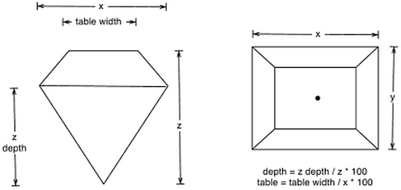

Carat is a unit of mass equal to 200 mg and is used for measuring gemstones and pearls. Cut grade is is an objective measure of a diamond’s light performance, or, what we generally think of as sparkle.

The figures below shows color grading of diamonds:

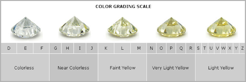

Lastly, the figure below shows clarity grading of diamonds:

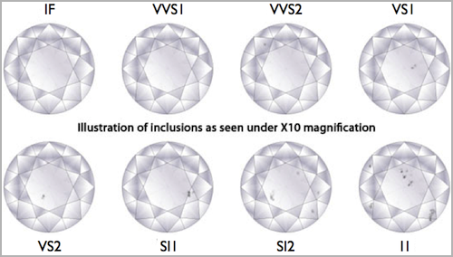

### Exploring variables individually

In the next section we will explore and visualize the distributions of the variables in this dataset individual. This type of analysis is also called **univariate analysis**.

First we should say a few words about classifying variables:

- **Numerical variables** can be classified as **continuous** or **discrete** based on whether or not the variable can take on an infinite number of values or only non-negative whole numbers, respectively.
- If the variable is **categorical**, we can determine if it is **ordinal** based on whether or not the levels have a natural ordering.

#### Exploring numerical data

When describing shapes of numerical distributions we highlight:

- shape:
  - right-skewed, left-skewed, symmetric (skew is to the side of the longer tail)
  - unimodal, bimodal, multimodal, uniform
- center: mean (`mean`), median (`median`), mode (not always useful)
  - spead: range (`range`), standard deviation (`sd`), inter-quartile range (`IQR`)
  - unusal observations

**Exercise 1:** What type of variable is price? Would you expect its distribution to be symmetric, right-skewed, or left-skewed? Why?

**Exercise 2:** Make a histogram of the distribution of diamond prices. Does the shape of the distribution match your expectation? Hint: Use `geom_histogram()`. See http://docs.ggplot2.org/current/geom_histogram.html for help.

Note that along with the plot, R printed out a warning for you:

```
stat_bin: binwidth defaulted to range/30. Use 'binwidth = x' to adjust
this.
```

**Exercise 3:** Try out a few other bin widths by adding the `binwidth` argument to the plot, until you find a bin width that’s too narrow and one that is too wide to produce a meaningful histogram.**

Earlier we learned about **aesthetics** and **facets**, which were attributes mapped to certain variables in the dataset. Unlike these, the argment `binwidth` is simply a **parameter** input that controls the appearance of the graph, but does not map appearance to data. Most parameters come with a default value, and different geoms use different aesthetics and parameters.

**Exercise 4:** Visualize the other numerical variables in the dataset and discuss any interesting features.**

When describing distributions of numerical variables we might also want to view statistics like mean, median, etc. (Functions for these are provided above, try a few.)

```r
diamonds %>%
  summarise(mean = mean(price), sd = sd(price), median = median(price))
```

#### Exploring categorical data

We can also summarize `cut`s of diamonds. Since this is a categorical variable we use tables. To create the table, first group by the **levels** of the cut variable, and then summarize the counts of diamonds in each level.

- Frequency table:

```r
diamonds %>%
  group_by(cut) %>%
  summarise(counts = n())
```

- Proportions table: Here we divide the counts in each level by the number of rows (observations) in the diamonds variable:

```r
diamonds %>%
  group_by(cut) %>%
  summarise(counts = n() / nrow(diamonds))
```

**Exercise 5:** What type of variable is color? Are all colors of diamonds (shown in the figure above) represented in the dataset? Which color is most prominently represented in the dataset?

A useful representation for categorical variables is a **bar plot**.

```r
ggplot(data = diamonds, aes(x = color)) +
  geom_bar()
```

**Exercise 6:** Make a bar plot of the distribution of `cut`, and describe its distribution.

### Bivariate relationships

Now that we are familiar with the individual variables in the dataset, we can start evaluating relationships between them.

#### Adding another variable to a histogram

Let’s make a histogram of the `depth`s of diamonds, with binwidth of 0.2%, and adding another variable (say, `cut`) to the visualization. We can do this either using an aesthetic or a facet:

- Using aesthetics: Use different colors to fill in for different cuts.

```r
ggplot(data = diamonds, aes(x = depth, fill = cut)) +
  geom_histogram(binwidth = 0.2)
```

- Using facets: Split into different plots for different cuts.

```r
ggplot(data = diamonds, aes(x = depth)) +
  geom_histogram(binwidth = 0.2) +
  facet_wrap(~ cut)
```

**Exercise 7:** Typical diamonds of which cut have the highest depth? On average, does depth increase or decrease as cut grade increase or decrease?

**Exercise 8:** Compare the distribution of price for the different cuts. Does anything seem unusual? Describe.

### More on plotting options

#### Position adjustments

Another parameter that can be passed to `qplot` is `position`. The options are

- `position = "identity"`: Don’t adjust position
- `position = "dodge"`: Adjust position by dodging overlaps to the side
- `position = "fill"`: Stack overlapping objects on top of one another, and standardise for comparable proportions across categories
- `position = "stack"`: Stack overlapping objects on top of one another
- `position = "jitter"`: Jitter points to avoid overplotting

**Exercise 9:** First to recreate the following plot:

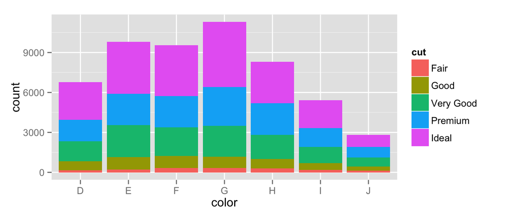

and then add position definitions to the `geom_bar` (e.g.) `geom_bar(position = "dodge")` and describe what you see. Note that not all options will work for categorical variables.

Next, let’s plot the relationship between price and carat for only diamonds with a `Fair` cut grading.

```r
fair_diamonds <- diamonds %>%
  filter(cut == "Fair")
ggplot(data = fair_diamonds, aes(x = price, y = carat)) +
  geom_point()
ggplot(data = fair_diamonds, aes(x = price, y = carat)) +
  geom_point(position = "jitter")
```

**Exercise 10:** Create a subset of diamonds that cost less than or equal to $1,000 (`<=`), and plot the relationship between price and carat with and without jittering. Do the plots look the same or different. What does this mean?

#### Zooming

You can also adjust the limits of your axes to zoom in on certain portions of the distribution.

Run the two following pieces of code to see how this option works:

```r
ggplot(data = diamonds, aes(x = carat, y = price)) +
  geom_point()
ggplot(data = diamonds, aes(x = carat, y = price)) +
  geom_point() +
  ylim(0, 2000) +
  xlim(0, 1)
```

**Exercise 11:** Describe the relationship between price and carat of diamonds.

### Further exploration

**Exercise 12:** Explore the distribution of carat. What can you see? What might explain that pattern? What carat weights are most common? Make sure to experiment with bin width!

**Exercise 13:** Look again at the relationship between price and carat. What do the data clustered in vertical lines in the plot tell us?

**Exercise 14:** Write down two questions that you could answer with these data, and use appropriate visualizations and summary statistics to answer them. Make sure at least one of these requires using multiple variables (through aesthetics and/or facets) at once. Be creative!